# sy2-案例

## **4.2条形图**

**plt.bar(x,height,width,bottom,align,color,edgecolor,data,kwargs)：**

1. `x`：一个数组或者列表，代表需要绘制的条形图的**x轴的坐标点**。
2. `height`：一个数组或者列表，代表需要绘制的条形图**y轴的坐标点**。
3. `width`：每一个条形图的宽度，默认是0.8的宽度。
4. `bottom`：y轴的基线，默认是0，也就是距离底部为0.
5. `align`：对齐方式，默认是center，也就是跟指定的x坐标居中对齐，  
   还有为edge，靠边对齐，具体靠右边还是靠左边，看width的正负。
6. `color`：条形图的颜色。
7. `edgecolor`:条形图的边框颜色。
8. `data`：如果传递了data，若data为一个DataFrame对象，x和height可以是某个列名。

### **4.2.1 条形图绘制**

- 比如现在有2019年贺岁片票房的数据，用条形图绘制每部电影及其票房的代码如下：

```python
#导包
import matplotlib.pyplot as plt
import numpy as np
import pandas as pd
plt.rcParams["font.sans-serif"] = ["SimHei"]
plt.rcParams["axes.unicode_minus"] = False  # 显示中文属性设置
```

```python
plt.rcParams["font.sans-serif"] = ["SimHei"]
plt.rcParams["axes.unicode_minus"] = False  # 显示中文属性设置
```

```python
movies = {
    "流浪地球": 40.78,
    "飞驰人生": 15.77,
    "疯狂的外星人": 20.83,
    "新喜剧之王": 6.10,
    "廉政风云": 1.10,
    "神探蒲松龄": 1.49,
    "小猪佩奇过大年": 1.22,
    "熊出没·原始时代": 6.71,
}  # 票房单位亿元
```

```python
np.arange(len(movies))
```

```
array([0, 1, 2, 3, 4, 5, 6, 7])
```

```python
movies.values()
```

```
dict_values([40.78, 15.77, 20.83, 6.1, 1.1, 1.49, 1.22, 6.71])
```

```python
movies.keys()
```

```
dict_keys(['流浪地球', '飞驰人生', '疯狂的外星人', '新喜剧之王', '廉政风云', '神探蒲松龄', '小猪佩奇过大年', '熊出没·原始时代'])
```

```python
list(movies.keys())
```

```
['流浪地球', '飞驰人生', '疯狂的外星人', '新喜剧之王', '廉政风云', '神探蒲松龄', '小猪佩奇过大年', '熊出没·原始时代']
```

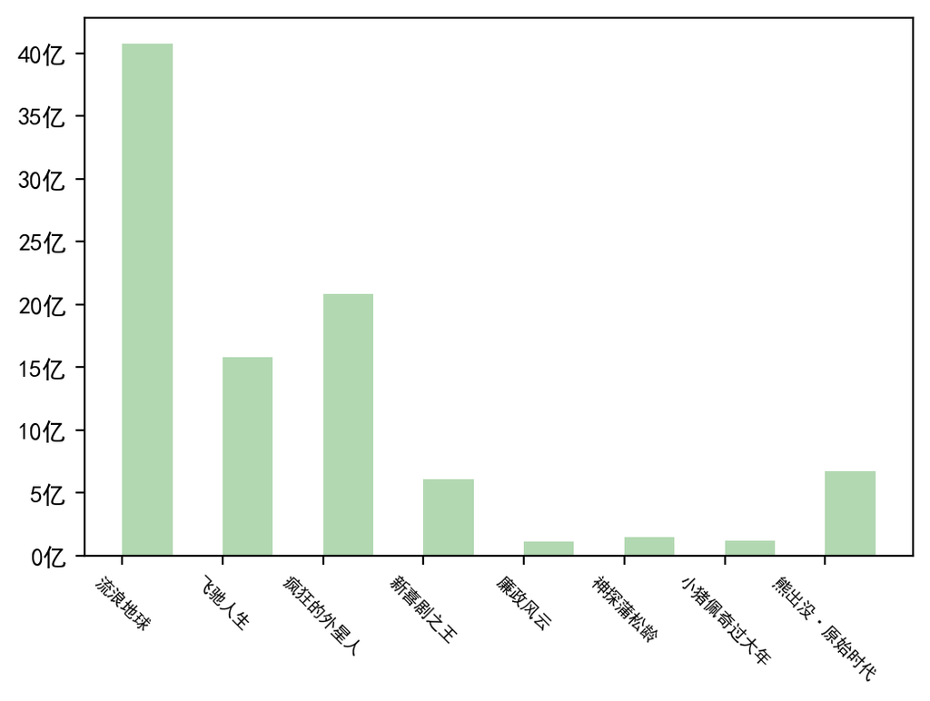

```python
movies = {
    "流浪地球": 40.78,
    "飞驰人生": 15.77,
    "疯狂的外星人": 20.83,
    "新喜剧之王": 6.10,
    "廉政风云": 1.10,
    "神探蒲松龄": 1.49,
    "小猪佩奇过大年": 1.22,
    "熊出没·原始时代": 6.71,
}  # 票房单位亿元

# plt.figure(figsize=(10,5),dpi=200)
plt.figure(dpi=200)
plt.bar(np.arange(len(movies)), list(movies.values()),
        width=0.5, color='g', alpha=0.3, align="edge")
plt.xticks(np.arange(len(movies)), list(movies.keys()), size=7, rotation=-45)
plt.yticks(range(0, 45, 5), ["%d亿" % i for i in range(0, 45, 5)])

plt.show()
```

### **4.2.3分组条形图**

```python
movies = {
    "流浪地球": [2.01, 4.59, 7.99, 11.83, 16],
    "飞驰人生": [3.19, 5.08, 6.73, 8.10, 9.35],
    "疯狂的外星人": [4.07, 6.92, 9.30, 11.29, 13.03],
    "新喜剧之王": [2.72, 3.79, 4.45, 4.83, 5.11],
    "廉政风云": [0.56, 0.74, 0.83, 0.88, 0.92],
    "神探蒲松龄": [0.66, 0.95, 1.10, 1.17, 1.23],
    "小猪佩奇过大年": [0.58, 0.81, 0.94, 1.01, 1.07],
    "熊出没·原始时代": [1.13, 1.96, 2.73, 3.42, 4.05],
}
```

```python
movies_arr = np.array(list(movies.values()))
movies_arr
```

```
array([[ 2.01,  4.59,  7.99, 11.83, 16.  ],
       [ 3.19,  5.08,  6.73,  8.1 ,  9.35],
       [ 4.07,  6.92,  9.3 , 11.29, 13.03],
       [ 2.72,  3.79,  4.45,  4.83,  5.11],
       [ 0.56,  0.74,  0.83,  0.88,  0.92],
       [ 0.66,  0.95,  1.1 ,  1.17,  1.23],
       [ 0.58,  0.81,  0.94,  1.01,  1.07],
       [ 1.13,  1.96,  2.73,  3.42,  4.05]])
```

归纳如下

```
<BarContainer object of 8 artists>
```

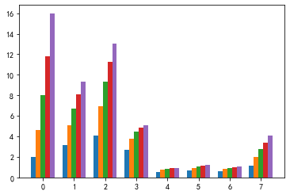

```python
x = np.arange(movies_arr.shape[0])
bar_width = 0.15
plt.bar(x - 2 * bar_width, movies_arr[:, 0], width=bar_width)
plt.bar(x - 1 * bar_width, movies_arr[:, 1], width=bar_width)
plt.bar(x, movies_arr[:, 2], width=bar_width)
plt.bar(x + 1 * bar_width, movies_arr[:, 3], width=bar_width)
plt.bar(x + 2 * bar_width, movies_arr[:, 4], width=bar_width)
```

颜色：['#c2e9fd', '#a1c4fd', '#8fd3f4', '#4facfe', '#a18cd1', '#fbc2eb', '#fad0c4', '#ff9a9e', '#fad0c4', '#ffdiff',]

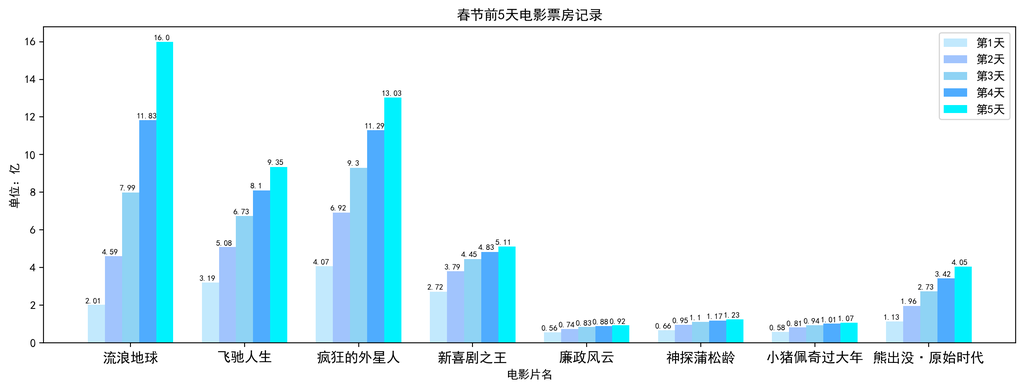

```python
bin_width = 0.15  # 每个条的宽度
coi = np.arange(movies_arr.shape[1])  # 每一列数据的索引(0,1,2,3,4),5天中每天的数据
x = np.arange(movies_arr.shape[0])  # x轴原始刻度(0,1,2,3,4,5,6,7)，8部影片
ColorList = ['#c2e9fd', '#a1c4fd', '#8fd3f4', '#4facfe', '#00f2fe']

plt.figure(figsize=(15, 5), dpi=200)
for i in coi:
    day_data = movies_arr[:, i]  # 提取出每一天的数据
    x_loc = x + (-2 + i) * bin_width  # 每条图像在x轴上的坐标
    plt.bar(x_loc, day_data, width=bin_width,color=ColorList[i], label="第%d天" % (i + 1))
    for value, xp in zip(day_data, x_loc):
        plt.annotate(value, xy=(xp, value), xytext=(xp - 0.1, value + 0.1), size=7)
plt.legend()
plt.xticks(x, movies.keys(), size=12)
plt.xlabel("电影片名")
plt.ylabel("单位：亿")
plt.title("春节前5天电影票房记录")
# plt.grid(True)
plt.show()
```